# AICodeDocumentation

Also, one thing that was slightly confusing is that chunk_text() isn't a member function. So instead of the tokenizer being referenced with self.tokenizer like it is during initialization and the embedding step, it is just tokenizer.

```python
    # Process a single text file with chunking.
    def process_file(self, filepath: Path) -> Tuple[str, np.ndarray]:
        self.logger.info(f"Processing file: {filepath}")

        try:
            # Read file
            with open(filepath, 'r', encoding='utf-8') as f:
                text = f.read()

            # Chunk text
            chunks = chunk_text(text, self.tokenizer)
            self.logger.info(f"Split into {len(chunks)} chunks")

            """***Continues to process the result of the chunks***"""
```

The first step of the chunk_text function is splitting it into sentences, which are stored in rough_chunks, and are then tokenized.

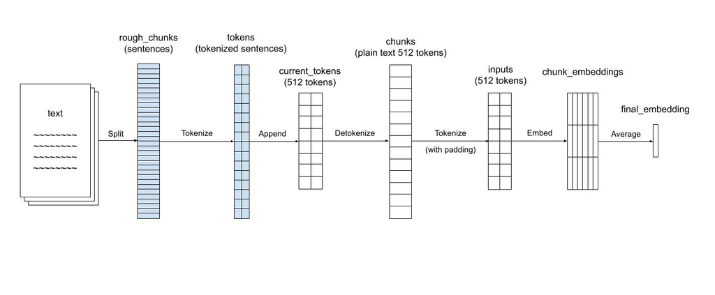

```python
# Split text into chunks based on token count, handling long sequences safely.
def chunk_text(text: str, tokenizer, chunk_size: int = 512) -> list:
    chunks = []

    # rough_chunks splits the text into sentences
    rough_chunks = [p for p in text.split('. ') if p.strip()]

    # current_chunk and current_length are used for having chunks be more than one sentence (used later in the function)
    current_chunk = []
    current_length = 0

    # try to tokenize every sentence (I had never seen tqdm before, but it just creates a progress bar for 'for' loops which is pretty cool)
    for rough_chunk in tqdm(rough_chunks, desc="Processing text chunks", leave=False):
        try:
            tokens = tokenizer.encode(rough_chunk + '.', add_special_tokens=False)

        """***Exception if tokenizing doesn't work***"""

        """***Does stuff with the tokens***"""
```

If the token fails (Joseph mentioned that this is most often due to the sentence being too long, which I don't know how often it happens), then it splits it into words, and then tries to tokenize groups of words that are about 200 characters. If there is still an error with the small piece, then it's not due to it being too long, so it's just discarded (and logged so we can see what wasn't tokenized).

```python
def chunk_text(text: str, tokenizer, chunk_size: int = 512) -> list:

    """***Creating rough chunks from sentences***"""

    for rough_chunk in tqdm(rough_chunks, desc="Processing text chunks", leave=False):
        try:
            tokens = tokenizer.encode(rough_chunk + '.', add_special_tokens=False)
        # If the tokenization fails
        except Exception as e:
            logger.warning(f"Error tokenizing chunk, splitting further: {str(e)}")
            # Split the sentence into words
            words = rough_chunk.split()

            tokens = []
            current_piece = []

            # For each word
            for word in words:
                # Create a list that will be tokenized (smaller than the original list)
                current_piece.append(word)
                # When the list is greater than 200 characters (which is smaller than 512, so it won't be too long)
                if len(' '.join(current_piece)) > 200:
                    # Attempt to tokenize the smaller chunk
                    try:
                        piece_tokens = tokenizer.encode(' '.join(current_piece) + '.', add_special_tokens=False)
                        # Create a list of all the tokens in the sentence
                        tokens.extend(piece_tokens)
                        current_piece = []
                    # If that still failed, then now it is just discarded
                    except Exception as e:
                        logger.error(f"Could not tokenize piece: {str(e)}")
                        current_piece = []
                        continue
            # After all the words, tokenize what remains of the list (since it was likely the last word wouldn't put it over 200 characters)
            if current_piece:
                try:
                    piece_tokens = tokenizer.encode(' '.join(current_piece) + '.', add_special_tokens=False)
                    tokens.extend(piece_tokens)
                except Exception as e:
                    logger.error(f"Could not tokenize final piece: {str(e)}")

        """***Does stuff with the tokens***"""
```

Now that the sentence has been tokenized, the next part tries to group the sentences together (since many sentences are less than 512 tokens, then the 512 chunk could be several sentences). This also takes care of the case where the sentence is greater than 512 tokens, and it will just split the sentence into 512 tokens. It will then decode the tokens and add them to chunks list that is returned.

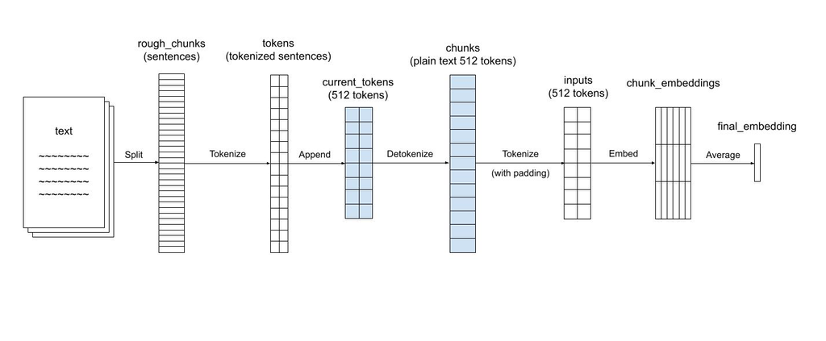

```python
def chunk_text(text: str, tokenizer, chunk_size: int = 512) -> list:

    """***Creating rough chunks from sentences***"""

    for rough_chunk in tqdm(rough_chunks, desc="Processing text chunks", leave=False):

        """***Created tokens from rough chunks***"""

        # current_length is the length of the chunk after the last sentence's tokens were added
        # current_chunk is the chunk after adding the tokens of the last sentence

        # If adding this sentence to the chunk would make it be larger than the max size
        if current_length + len(tokens) > chunk_size and current_chunk:
            # Convert the chunk back into text (the previous chunk before adding the new sentence)
            chunk_text = tokenizer.decode(current_chunk)
            # Not quite sure what the strip function is doing here (maybe ensuring that an empty chunk of just spaces doesn't get added to the list)
            if chunk_text.strip():
                # Add the current chunk to the list that is returned
                chunks.append(chunk_text.strip())
            current_chunk = []
            current_length = 0

        # If the current sentence is bigger than the max size
        if len(tokens) > chunk_size:
            # This part isn't done too cleanly, just split it up into exactly 512 token parts
            for i in range(0, len(tokens), chunk_size):
                sub_tokens = tokens[i:i + chunk_size]
                # Decode the tokens
                sub_text = tokenizer.decode(sub_tokens)
                # And then add the chunk to the list that is returned
                if sub_text.strip():
                    chunks.append(sub_text.strip())

        # Otherwise, it is within the maximum size, so just add it to the current_chunk list and move onto the next chunk
        else:
            current_chunk.extend(tokens)
            current_length += len(tokens)

        # Okay, I'm kind of lost on the purpose of this if statement, as the current length wouldn't bigger than the max size due to the two previous if statements
        # If there is just a case I'm not thinking of, then if the length of the chunk is greater than the current size
        if current_length >= chunk_size:
            # Decode the tokens
            chunk_text = tokenizer.decode(current_chunk)
            # And add the text to the list that is returned
            if chunk_text.strip():
                chunks.append(chunk_text.strip())
            current_chunk = []
            current_length = 0

    ## Leaving the big for loop of going through each sentence

    # For the last sentence, if it wasn't already added to the list
    if current_chunk:
        # Decode it
        chunk_text = tokenizer.decode(current_chunk)
        # And add it to the list that is returned
        if chunk_text.strip():
            chunks.append(chunk_text.strip())


    # The list of chunks is returned
    return chunks
```

With the list of the chunks, the process returns to the process_file function. A folder is created to hold the all of the individual embeddings (not just the average), and then every chunk is passed to the process_chunk function to create the embedding, and is stored in the created folder.

There is one part in this section that seems like it could be removed. In both of the 'for' loops, the embeddings are calculated, which seems to be unnecessary. If instead the first 'for' loop calculated the embeddings and the second just stored them, it would be much more efficient (The reason I can see to not just do it all in one loop is that if an error is thrown, then the folder wouldn't be created just to be blank or only hold a part of the embeddings, but maybe we do want this for logging purposes).

```python
    def process_file(self, filepath: Path) -> Tuple[str, np.ndarray]:
        try:

            """***Chunk text***"""

            # Process each chunk
            chunk_embeddings = []
            for chunk in tqdm(chunks, desc="Processing chunks"):
                # Create the embedding from the chunk
                embedding = self.process_chunk(chunk)
                # Add embedding to list of embeddings
                chunk_embeddings.append(embedding)


            # Take the file name and add the time stamp to it (which should create a unique id even if the code is run on the same input twice)
            job_id = f"job_{filepath.stem}_{datetime.now().strftime('%Y%m%d_%H%M%S')}"

            # Create directory for all of the embeddings
            chunk_dir = self.results_dir / job_id / 'chunks'
            chunk_dir.mkdir(parents=True, exist_ok=True)

            # Process each chunk, storing them in chunk_embeddings
            # ALREADY DECLARED
            chunk_embeddings = []
            for i, chunk in enumerate(tqdm(chunks, desc="Processing chunks")):

                # REPEATED CODE
                embedding = self.process_chunk(chunk)
                chunk_embeddings.append(embedding)
                # END OF REPEATED CODE

                # Save individual chunk embedding
                chunk_result = {
                    'chunk_text': chunk,
                    'embedding': embedding.tolist(),
                    'chunk_index': i
                }
                with open(chunk_dir / f'chunk_{i}.json', 'w') as f:
                    json.dump(chunk_result, f, indent=2)

            """***Average and save final embedding***"""
```

The process chunk will take the plain text and create the padded tokens and then create the embeddings.

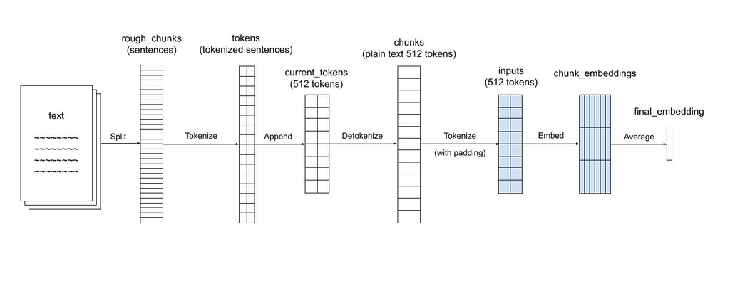

```python
    # Process a single chunk of text and return its embedding.
    def process_chunk(self, chunk: str) -> np.ndarray:
        try:
            # This is creating the tokens again, but this time it pads the tokens, so every input is exactly 512 tokens long (if it somehow was too long, it will also truncate it)
            inputs = self.tokenizer(
                chunk,
                padding=True,
                truncation=True,
                max_length=512,
                return_tensors="pt"
            ).to(self.device)

            # The torch.no_grad is turning off calculating the gradients, which looking into it, helps perform better when you don't need to use backpropagation (which we aren't training the model)
            with torch.no_grad():
                # https://huggingface.co/docs/transformers/v4.48.2/en/main_classes/output#transformers.modeling_outputs.SequenceClassifierOutput
                # This is what I've found so far to explain how this section works

                # This is giving the model the list of the tokens and creates a SequenceClassifierOutput
                outputs = self.model(**inputs)

                # This is then calculating the embeddings
                # (the pooler_output means that it is going though a linear layer and tanh activation, which I need to read more about to better understand)
                embedding = outputs.pooler_output.cpu().numpy()
            # To my understanding, the pooler_output can do several chunks at the same time, so it returns a matrix, but we only want the first value, since we are only doing one embedding
            return embedding[0]
        # If something went wrong, then throw an error (I'm pretty sure this will stop the entire process_file function)
        except Exception as e:
            self.logger.error(f"Error processing chunk: {str(e)}")
            raise
```

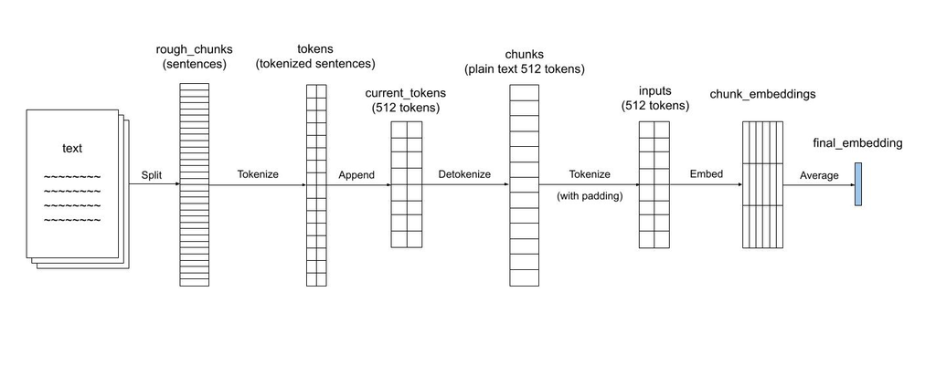

```python
    def process_file(self, filepath: Path) -> Tuple[str, np.ndarray]:
        try:

            """***Chunk text***"""

            """***Create embeddings***"""


            # If there are no embeddings, then they can't be averaged
            if not chunk_embeddings:
                raise ValueError("No valid chunks processed")

            # Average embeddings
            final_embedding = np.mean(chunk_embeddings, axis=0)

            # Save results
            result = {
                job_id: {
                    'text': text,  # original text
                    'embedding': final_embedding.tolist(),
                    'metadata': {
                        'filename': filepath.name,
                        'processed_at': datetime.now().isoformat(),
                        'num_chunks': len(chunks),
                        'file_size': filepath.stat().st_size
                    }
                }
            }

            # Save to JSON

            timestamp = datetime.now().strftime('%Y%m%d_%H%M%S')
            # Create the file in the embedding_results directory
            result_file = self.results_dir / f'embedding_{filepath.stem}_{timestamp}.json'

            # Store the data into the JSON file
            with open(result_file, 'w') as f:
                json.dump(result, f, indent=2)

            # Once the data has been put into the file, it is then moved from embedding_results directory to processed directory
            dest_path = self.processed_dir / filepath.name
            shutil.move(str(filepath), str(dest_path))

            # The embeddings were all succesfully made, and the average embedding is stored in data/processed
            self.logger.info(f"Successfully processed {filepath}")
            return job_id, final_embedding

        # If something did go wrong in processing the file, then raise an error, which will just move onto the next file
        except Exception as e:
            self.logger.error(f"Error processing file {filepath}: {str(e)}")
            error_path = self.error_dir / filepath.name
            shutil.move(str(filepath), str(error_path))
            raise
```

With the embedding for this file made, it continues to loop through each file and create the embeddings

At the end:

data/embedding_results : Holds every chunk embedding